# LAB 3 Data Visualization

Aryan Vigyat 20BCE1452

2023-01-06

Instantiating the Required Libraries

```r
library(dplyr)
```

```r
library(readr)
library(corrplot)
library(RColorBrewer)
library(ggplot2)
library(GGally)
```

1. Loading the Dataset

```r
df=read_csv("C:/Users/ayuar/Downloads/churn_data.csv.zip")
head(df,5)
```

```
## # A tibble: 5 × 31
##    user churn   age housing credit_score depos…¹ withd…² purch…³ purch…⁴ cc_ta…⁵
##   <dbl> <dbl> <dbl> <chr>          <dbl>   <dbl>   <dbl>   <dbl>   <dbl>   <dbl>
## 1 55409     0    37 na                NA       0       0       0       0       0
## 2 23547     0    28 R                486       0       0       1       0       0
## 3 58313     0    35 R                561      47       2      86      47       0
## 4  8095     0    26 R                567      26       3      38      25       0
## 5 61353     1    27 na                NA       0       0       2       0       0
## # … with 21 more variables: cc_recommended <dbl>, cc_disliked <dbl>,
## #   cc_liked <dbl>, cc_application_begin <dbl>, app_downloaded <dbl>,
## #   web_user <dbl>, app_web_user <dbl>, ios_user <dbl>, android_user <dbl>,
## #   registered_phones <dbl>, payment_type <chr>, waiting_4_loan <dbl>,
## #   cancelled_loan <dbl>, received_loan <dbl>, rejected_loan <dbl>,
## #   zodiac_sign <chr>, left_for_two_month_plus <dbl>, left_for_one_month <dbl>,
## #   rewards_earned <dbl>, reward_rate <dbl>, is_referred <dbl>, and …
```

```r
df<-na.omit(df)
```

2. Selecting the Attributes for Correlation

```r
df <- df %>%
  select_if(is.numeric)
M<-cor(df[,4:12])
```

3. Drawing all the Correlation Plots

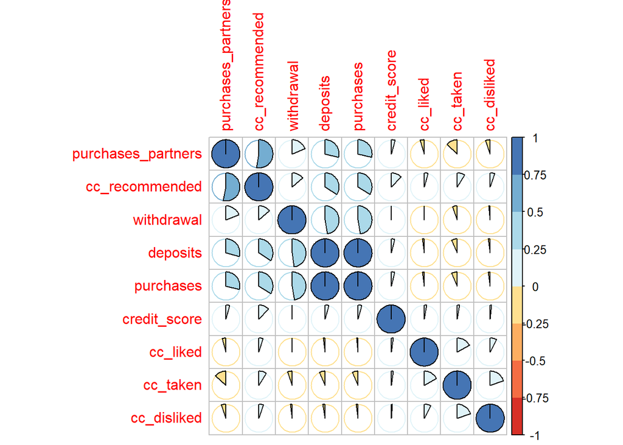

```r
corrplot(M,method="pie",order="hclust",
         col=brewer.pal(n=8, name="RdYlBu"))
```

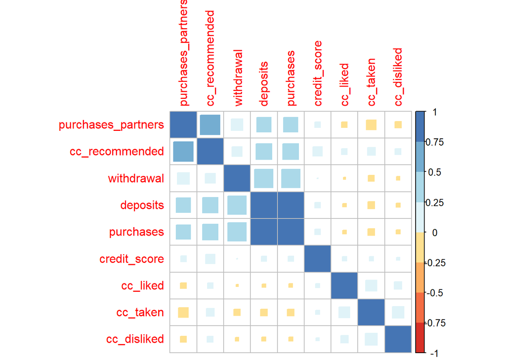

```r
corrplot(M, method = "square",order="hclust",
         col=brewer.pal(n=8, name="RdYlBu"))
```

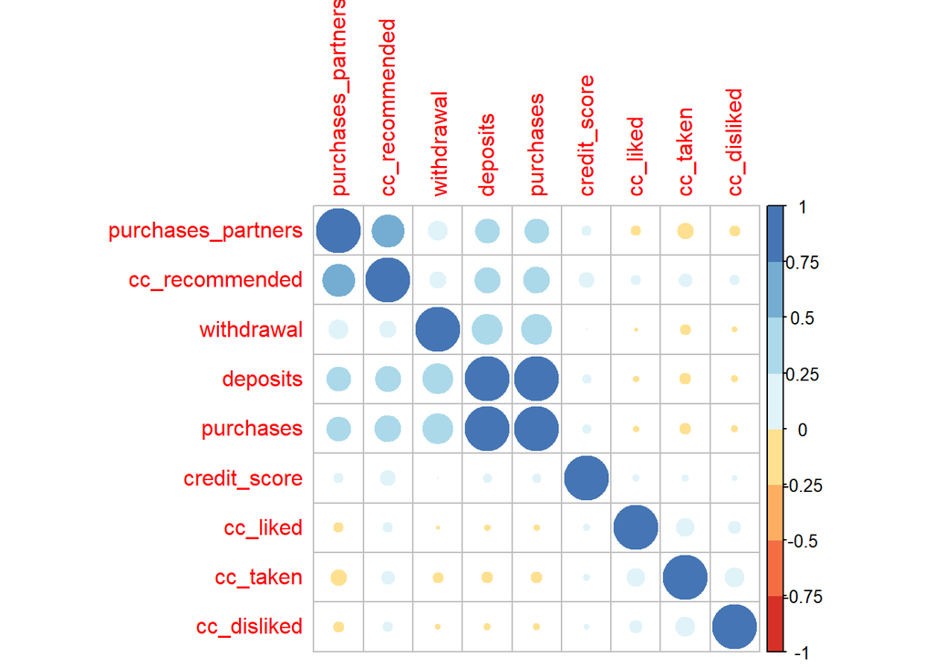

```r
corrplot(M, method = "circle",order="hclust",
         col=brewer.pal(n=8, name="RdYlBu"))
```

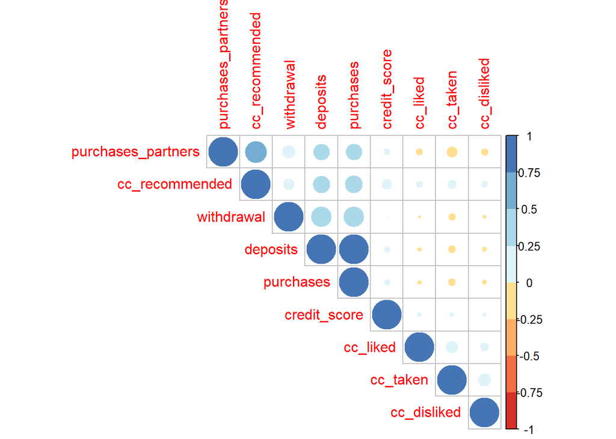

```r
corrplot(M, type="upper",order="hclust",
         col=brewer.pal(n=8, name="RdYlBu"))
```

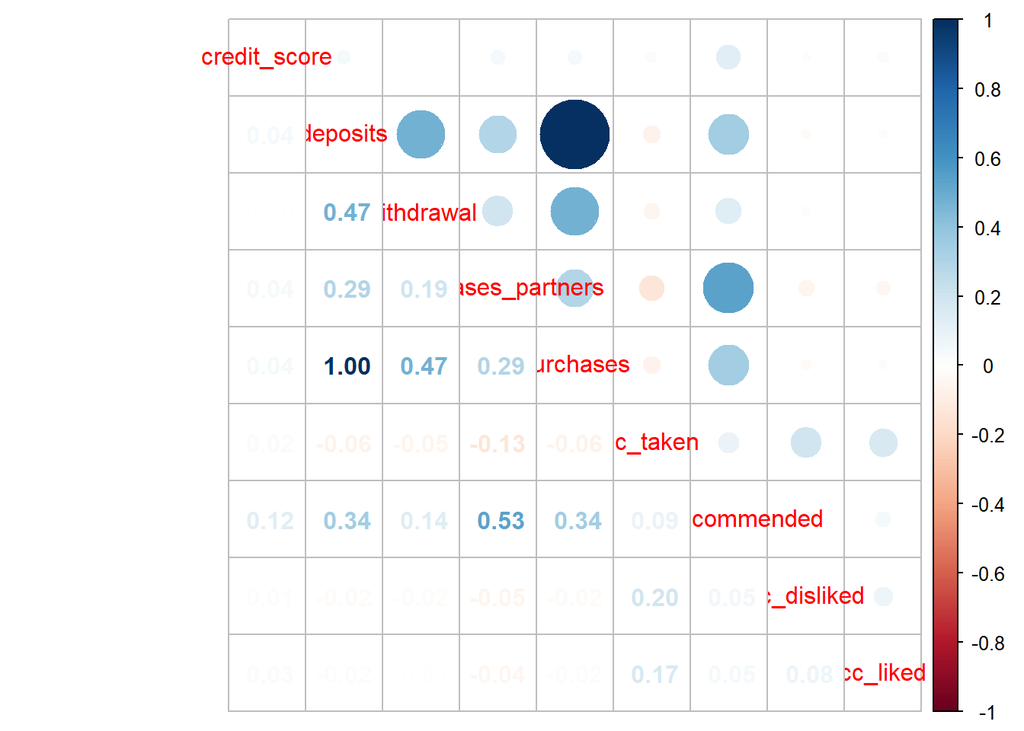

```r
corrplot.mixed(M)
```

4. Scatterplots for checking correlation

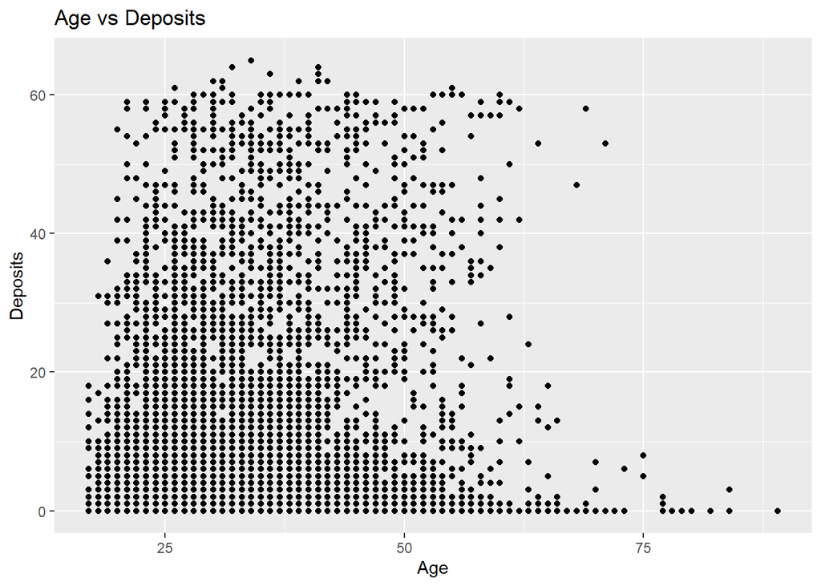

```r
ggplot(df,aes(x=age,y=deposits))+geom_point()+ggtitle("Age vs Deposits")+xlab("Age")+ylab("Deposits")
```

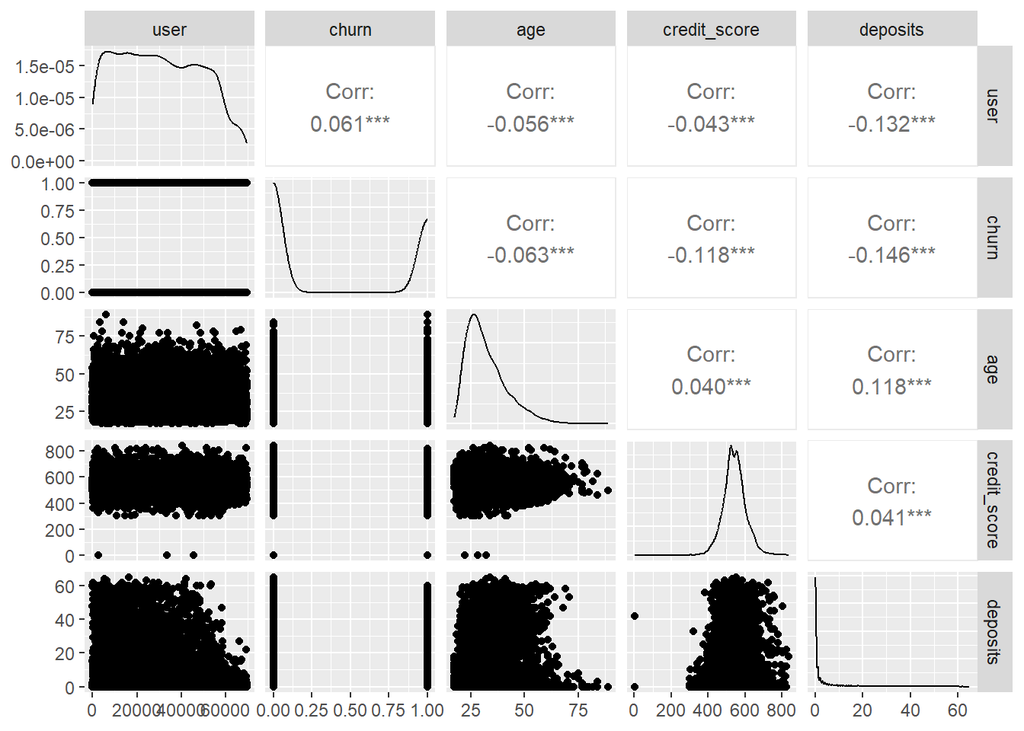

```r
ggpairs(df[,1:5])
```

2<sup>nd</sup> Dataset - (Orange)

```r
library(datasets)
summary(Orange)
```

```
##  Tree       age         circumference
##  3:7   Min.   : 118.0   Min.   : 30.0
##  1:7   1st Qu.: 484.0   1st Qu.: 65.5
##  5:7   Median :1004.0   Median :115.0
##  2:7   Mean   : 922.1   Mean   :115.9
##  4:7   3rd Qu.:1372.0   3rd Qu.:161.5
##        Max.   :1582.0   Max.   :214.0
```

```r
View(Orange)
head(Orange,5)
```

```
##   Tree  age circumference
## 1    1  118            30
## 2    1  484            58
## 3    1  664            87
## 4    1 1004           115
## 5    1 1231           120
```

Question 1: Age is a Ratio Variable,Circumference is a ratio Variable and Tree is a Interval Data Type  
Question 2:

```r
mean(Orange$circumference)
```

```
## [1] 115.8571
```

```r
sd(Orange$circumference)
```

```
## [1] 57.48818
```

```r
sd(Orange$circumference)/sqrt(length((Orange$circumference)))
```

```
## [1] 9.717276
```

Question 3:

```r
model1<-lm(circumference~age,data=Orange)
model1
```

```
##
## Call:
## lm(formula = circumference ~ age, data = Orange)
##
## Coefficients:
## (Intercept)          age
##     17.3997       0.1068
```

Coefficients

- Intercept means the constant in the Y Axis.
- The Second Value Give the Slope of the Linear Model

Question 4:

```r
model2<-lm(age~circumference,data=Orange)
summary(model1)
```

```
##
## Call:
## lm(formula = circumference ~ age, data = Orange)
##
## Residuals:
##     Min      1Q  Median      3Q     Max
## -46.310 -14.946  -0.076  19.697  45.111
##
## Coefficients:
##              Estimate Std. Error t value Pr(>|t|)
## (Intercept) 17.399650   8.622660   2.018   0.0518 .
## age          0.106770   0.008277  12.900 1.93e-14 ***
## ---
## Signif. codes:  0 '***' 0.001 '**' 0.01 '*' 0.05 '.' 0.1 ' ' 1
##
## Residual standard error: 23.74 on 33 degrees of freedom
## Multiple R-squared:  0.8345, Adjusted R-squared:  0.8295
## F-statistic: 166.4 on 1 and 33 DF,  p-value: 1.931e-14
```

```r
summary(model2)
```

```
##
## Call:
## lm(formula = age ~ circumference, data = Orange)
##
## Residuals:
##     Min      1Q  Median      3Q     Max
## -317.88 -140.90  -17.20   96.54  471.16
##
## Coefficients:
##               Estimate Std. Error t value Pr(>|t|)
## (Intercept)    16.6036    78.1406   0.212    0.833
## circumference   7.8160     0.6059  12.900 1.93e-14 ***
## ---
## Signif. codes:  0 '***' 0.001 '**' 0.01 '*' 0.05 '.' 0.1 ' ' 1
##
## Residual standard error: 203.1 on 33 degrees of freedom
## Multiple R-squared:  0.8345, Adjusted R-squared:  0.8295
## F-statistic: 166.4 on 1 and 33 DF,  p-value: 1.931e-14
```

Question 5: Inferences

- The R-Square Value for the both the models is 0.83 so 83 percent of the variance in the Dataset is explained by the Model and also Considering the P-Value (<0.05) so we Say the Model is a good fit
- For the First Model the median is closer to 0 than the Second model

Question 6:

```r
x=Orange$age
y=Orange$circumference
pcor=cor(x,y,method="pearson")
print(pcor)
```

```
## [1] 0.9135189
```

Its closer to 1, so strongly correlated  
Question 7:  
Yes The P-Value obtained is 1.931e-14. value of less than 0.05 .Therefore you determine,that it is statistically significant.